# Hypothesis Testing, Randomization Inference

Shikhar Singh

September 9, 2026

# Agenda

### 1. Multiple Treatments

- Generalized Switching Equation
- Randomization with Multiple Arms in `randomizr`

### 2. Hypothesis Testing

- Types of Null Hypotheses
- Definition of P-Value

### 3. Randomization Inference

### 4. One and Two-Tailed Hypothesis Tests

# Multiple Treatments

So far we have discussed a two-arm design in which subjects are randomly assigned to a “treatment” or “control” group. However, often field experiments have multiple interventions, the efficacy of which is simultaneously tested against a control group.

> For a two-arm trial, the switching equation is: $Y_i = d_i\cdot Y_i(1) + (1-d_i)\cdot Y_i(0)$. The generalized form of this uses a series of indicator variables, $\mathbb{1}$. Specifically: $Y_i = \mathbb{1}_{d_i=0} \cdot Y_i(0) + \mathbb{1}_{d_i=1} \cdot Y_i(1) + \mathbb{1}_{d_i=2} \cdot Y_i(2) + \cdots + \mathbb{1}_{d_i=k} \cdot Y_i(k)$

We use the `case_when` command to operationalize this equation in R.

The code below shows how to assign subjects to four conditions. Exactly 150 are assigned to C, 250 to T1, 400 to T2, and 200 to T3. We then use the generalized switching equation to create a new column of observed outcomes, $Y_i$ (observed outcome).

```r
library(tidyverse)
library(randomizr)
library(knitr)

dat1 <- tibble(
  Y0 = rnorm(1000),
  Y1 = Y0 + rnorm(1000, mean = 5, sd = 1),
  Y2 = Y0 - rnorm(1000, mean = 5, sd = 1),
  Y3 = Y0 * rnorm(1000, mean = 5, sd = 1)
)

dat1 <- dat1 %>%
  mutate(
    d_multi_arm = complete_ra(N = 1000, m_each = c(150, 250, 400, 200),
                              conditions = c("C", "T1", "T2", "T3")),
    y_obs = case_when(
      d_multi_arm == "C" ~ Y0,
      d_multi_arm == "T1" ~ Y1,
      d_multi_arm == "T2" ~ Y2,
      d_multi_arm == "T3" ~ Y3
    )
  )
```

**Check #1:** Checking if treatment assignment is done correctly

| d_multi_arm | N |
| --- | --- |
| C | 150 |
| T1 | 250 |
| T2 | 400 |
| T3 | 200 |

**Check #2:** Checking if the switching equation works correctly

| Y0 | Y1 | Y2 | Y3 | d_multi_arm | y_obs |
| --- | --- | --- | --- | --- | --- |
| -0.4046054 | 4.4540814 | -4.809483 | -2.0256724 | T2 | -4.8094835 |
| -2.4246869 | 0.5842471 | -7.234526 | -12.4513465 | C | -2.4246869 |
| 0.5700763 | 4.7386814 | -4.557838 | 2.3368152 | T2 | -4.5578379 |
| 0.0934843 | 5.9429831 | -5.286678 | 0.3815413 | C | 0.0934843 |
| -1.5833416 | 3.4038520 | -7.384418 | -6.2049484 | C | -1.5833416 |
| -2.4041855 | 2.5094525 | -7.345403 | -17.3739450 | C | -2.4041855 |
| 0.2827259 | 4.1935833 | -4.990372 | 1.1446299 | T3 | 1.1446299 |
| -2.1385968 | 2.1954217 | -5.139534 | -10.6565026 | T3 | -10.6565026 |
| -0.9337027 | 5.2040057 | -5.034051 | -3.8215962 | C | -0.9337027 |
| -1.1911330 | 4.9049178 | -7.360226 | -8.4441624 | T2 | -7.3602261 |

# Hypothesis Testing

Say we run an experiment and obtain an average treatment effect, $\widehat{\mathbb{E}[\tau_i]}$. A natural next-step is to ask: did we get this estimate by “chance” or is there a low probability of observing such an effect if the null hypothesis of no-effect were true? This is called hypothesis testing.

## Null Hypotheses

The basic intuition of a hypothesis test is to ask the following question: how likely are we to observe the estimate we get or larger assuming the null hypothesis were true. So what is a null hypothesis?

**Conventional Null Hypothesis:** “The average treatment effect is zero. Formally, $\mu_{Y(1)} = \mu_{Y(0)}$.” (FEDAI: 62)

**Sharp Null Hypothesis:** “The effect is zero for all subjects. Formally, $Y_i(1) = Y_i(0) \forall i$” (FEDAI: 62)

**Sharp and Conventional Null:** The sharp null hypothesis of no effect stipulates that $\tau_i = 0$ for all $i$. By implication $\mathbb{E}[\tau_i] = 0$ or the average treatment effect is also 0. This means the sharp null hypothesis is a *stronger assumption* about no-effect than the conventional null hypothesis (average effect can be 0 even when $\tau_i$ is non-zero for many or all subjects).

**FPCI and Sharp Nulls:** An interesting property of the sharp null hypothesis is that if $Y_i(1) = Y_i(0)$, then we observe both potential outcomes for all subjects.

Potential Outcomes Under Sharp Null

| Unit | Truth Y(1) | Truth Y(0) | d_i | Observed Y1 | Observed Y0 | Sharp Null y1 | Sharp Null y0 |
| --- | --- | --- | --- | --- | --- | --- | --- |
| 1 | 10 | 15 | 1 | 10 | ? | 10 | 10 |
| 2 | 10 | 13 | 1 | 10 | ? | 10 | 10 |
| 3 | 16 | 11 | 0 | ? | 11 | 11 | 11 |
| 4 | 8 | 9 | 0 | ? | 9 | 9 | 9 |

## P Value

For a two-tailed test, the p-value is the probability of obtaining a test statistic at least as large in absolute value as the observed test statistic, given that the null hypothesis is true. (FEDAI:64)

**Intuition:** Last class we covered sampling distributions. Think of the sampling distribution for a parameter (difference-in-means) under the sharp null hypothesis. It will be centered on 0. That is, the expected value of the parameter under the null hypothesis is 0. Now imagine that we run an experiment get a difference-in-means estimate of 5. A *p value* tells us the probability of obtaining a DIM estimate greater than or equal to 5 **OR** lesser than or equal to -5 in the null distribution.

# Randomization Inference

> Randomization inference refers to “[t]he sampling distribution of the test statistic under the null hypothesis, computed by simulating all possible random assignments. When the number of random assignments is too large to simualate, the sampling distribution may be approximated by a large random sample of possible assignments. p-values are calculated by comparing the observed test statistic to the distribution of test statistics under the null hypothesis.” (FEDAI:64)

The steps involved in this hypothesis test are as follows:

1. Given some data, we only observe $Y_i(1)$ for treatment group subjects and $Y_i(0)$ for control group subjects. This is the observed outcome or $Y_i$. The data set also contains a column with each subject’s treatment status, or $d_i$. This is one of several possible assignment vectors that randomly assigns subjects to treatment and control conditions.
2. Estimate the average treatment effect using the difference-in-means estimator, given the observed data. Call this $\widehat{\theta}$.
3. Use `mutate` to create two new columns: $Y^0_{\text{null}}$ and $Y^1_{\text{null}}$. Under the sharp null hypothesis, the observed $Y_i = Y^0_{\text{null}} = Y^1_{\text{null}}$.
4. Draw a new treatment status vector, $d^*_i$, apply the switching equation to $Y^0_{\text{null}}$ and $Y^1_{\text{null}}$ to get the observed outcome $Y^*_i$ given this treatment status vector, and estimate the average treatment effect. Repeat this process a large number of times, storing the estimate of the average treatment effect in each iteration.
5. The resulting sampling distribution will be centered on 0. It is the sampling distribution of the ATE under the sharp null hypothesis. We are interested in knowing the probability of observing $\widehat{\theta}$ or more extreme (i.e $|\theta| \geq |\widehat{\theta}|$), given the sampling distribution under the sharp null hypothesis. Formally, $p(|\theta| \geq |\widehat{\theta}|)$ for a two-tailed p value.

**P Value Interpretation:** If randomization inference yields a large p value, say $p=0.4$, this is **not** evidence in support of the sharp null hypothesis. This p value tells us that there is a 40% chance of observing the estimate we get from the data or more extreme, *assuming* the null hypothesis is correct.

## RI in R

I will create some data where $Y_1$ and $Y_0$ are *unobserved* potential outcomes. Assume that we are randomly assigning each subject $i$ to a treatment condition ($d_i=1$) or control condition ($d_i=0$).

Given the data generating process, the true ATE or $E[Y_i(1) - Y_i(0)] \approx 2$ but note $\tau_i \neq 2$ $\forall i$.

```r
dat3 <- tibble(Y0 = rnorm(100, mean = 0, sd = 8),
               Y1 = Y0 + rnorm(100, mean = 2, sd = 1))

kbl(head(dat3), caption = "Dataset for Randomization Inference", row.names = T) %>%
  kable_classic()
```

Dataset for Randomization Inference

|  | Y0 | Y1 |
| --- | --- | --- |
| 1 | -4.333812 | -2.924986 |
| 2 | 14.022270 | 16.718717 |
| 3 | -15.319552 | -12.735798 |
| 4 | 1.348260 | 2.966116 |
| 5 | -6.945779 | -5.560539 |
| 6 | -4.466210 | -5.273829 |

```r
dat3 %>% summarise(`True ATE` = mean(Y1 - Y0)) %>% kable()
```

| True ATE |
| --- |
| 1.993303 |

**Step 1:** For the experiment, we assign exactly $m=50$ of $N=100$ subjects to treatment. This is $d_i$.

```r
# Step 1: Create an assignment vector (i.e. the "realized" or "actual" assignment status)

dat3 <- dat3 %>%
  mutate(d_i = complete_ra(N = 100, m = 50),
         y_i = Y1 * d_i + (1 - d_i) * Y0)

kbl(dat3 %>% select(y_i, d_i) %>% head(),
      caption = "Observed Data",
      row.names = T) %>%
  kable_classic()
```

Observed Data

|  | y_i | d_i |
| --- | --- | --- |
| 1 | -4.333812 | 0 |
| 2 | 16.718717 | 1 |
| 3 | -15.319552 | 0 |
| 4 | 1.348260 | 0 |
| 5 | -5.560539 | 1 |
| 6 | -5.273829 | 1 |

**Step 2:** Estimate the difference in means, $\widehat{\theta}$

```r
ate_estimate = dat3 %>% summarise(`DIM` = mean(y_i[d_i==1]) - mean(y_i[d_i==0]))

kable(ate_estimate) %>%
  kable_classic()
```

| DIM |
| --- |
| 3.051327 |

**Step 3:** Use mutate to create two new columns: $Y^0_{\text{null}}$ and $Y^1_{\text{null}}$. Under the sharp null hypothesis, the observed $Y_i = Y^0_{\text{null}} = Y^1_{\text{null}}$

```r
dat3 <- dat3 %>%
  mutate(y1_null = y_i,
         y0_null = y_i,)

kbl(
  dat3 %>% select(y_i, d_i, y1_null, y0_null) %>% head(),
  caption = "Data Under the Sharp Null Hypothesis of No Effect",
  row.names = T
) %>%
  kable_classic()
```

Data Under the Sharp Null Hypothesis of No Effect

|  | y_i | d_i | y1_null | y0_null |
| --- | --- | --- | --- | --- |
| 1 | -4.333812 | 0 | -4.333812 | -4.333812 |
| 2 | 16.718717 | 1 | 16.718717 | 16.718717 |
| 3 | -15.319552 | 0 | -15.319552 | -15.319552 |
| 4 | 1.348260 | 0 | 1.348260 | 1.348260 |
| 5 | -5.560539 | 1 | -5.560539 | -5.560539 |
| 6 | -5.273829 | 1 | -5.273829 | -5.273829 |

**Step 4:** Draw a new treatment status vector, $d^*_i$, apply the switching equation to get the observed outcome $Y_i$ given this treatment status vector, and estimate the average treatment effect. Repeat this process a large number of times, storing the estimate of the average treatment effect in each iteration.

```r
# Obtain a permutation matrix (all possible assignment vectors)
declaration = declare_ra(N = nrow(dat3), m=50)

D <- obtain_permutation_matrix(declaration)

# Obtain sampling distribution under the sharp null
ests_sharp_null <- c()

for(i in 1:ncol(D)) {
  dat3$d_temp <- D[, i]
  estimate_sharp_null <-
    dat3 %>% summarise(`DIM` = mean(y_i[d_temp == 1]) - mean(y_i[d_temp == 0]))
  ests_sharp_null = bind_rows(ests_sharp_null, estimate_sharp_null)
}

kbl(ests_sharp_null %>% head(),
      caption = "Sampling Distribution Under the Sharp Null Hypothesis",
      row.names = T) %>%
  kable_classic()
```

Sampling Distribution Under the Sharp Null Hypothesis

|  | DIM |
| --- | --- |
| 1 | -3.0111307 |
| 2 | 0.3825039 |
| 3 | -1.5551952 |
| 4 | 0.6809682 |
| 5 | -1.1920217 |
| 6 | 1.1581331 |

```r
ggplot(data = ests_sharp_null, aes(x = DIM)) +
  geom_histogram(bins = 50) +
  geom_vline(xintercept = 0,
             linetype = "dashed",
             color = "blue") +
  xlab("Estimates") +
  ylab("Frequency") +
  ggtitle("Sampling Distribution Under the Sharp Null Hyp.") +
  theme_bw(base_size = 14)
```

[figure not shown]

**Step 5:** Calculate $p(|\theta| \geq |\widehat{\theta}|)$ to get the two-sided p-value.

```r
p_values = ests_sharp_null %>% summarise(
  `One Sided P Value` = mean(DIM >= ate_estimate$DIM),
  `Two Sided P Value` = mean(abs(DIM) >= abs(ate_estimate$DIM))
)

kable(p_values, digits = 5) %>%
  kable_classic()
```

| One Sided P Value | Two Sided P Value |
| --- | --- |
| 0.0186 | 0.038 |

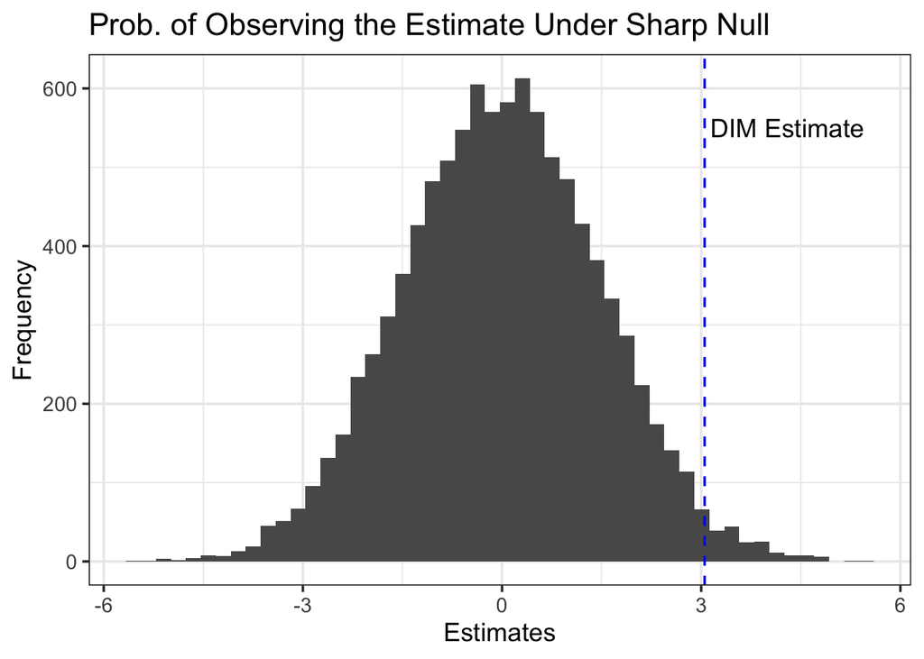

```r
ggplot(data = ests_sharp_null, aes(x = DIM)) +
  geom_histogram(bins = 50) +
  geom_vline(xintercept = ate_estimate$DIM,
             linetype = "dashed",
             color = "blue") +
  geom_text(data = ate_estimate, aes(y = 550, x = DIM + 1.25, label = "DIM Estimate")) +
  xlab("Estimates") + ylab("Frequency") +
  ggtitle("Prob. of Observing the Estimate Under Sharp Null") +
  theme_bw(base_size = 14)
```

ADVANCED

> T-Tests, which we typically use for hypothesis tests using conventional null hypotheses, *assume* that the sampling distribution has a certain shape. For example, in large samples, the null distribution would be centered on 0 and approximate a Normal distribution. Hypothesis testing using randomization inference and sharp nulls is *non-parametric*. We do not have to assume that the null distribution has a particular shape. Since we have the potential outcomes, $Y^0_{\text{null}}$ and $Y^1_{\text{null}}$, for all observations, we can retrieve the exact null distribution itself. If the number of possible randomizations is very large, we can approximate the null distribution by simulating a large number of random assignments.

# One Vs. Two-Tailed Tests

**One-Tailed Test:** In the randomization inference procedure we just covered, say we observe a DIM estimate of $\widehat{\theta}$. For a positive effect, a one-tailed test calculates the probability, $p(\theta \geq \widehat{\theta})$ (density in the upper tail of the null distribution). For a negative effect, a one-tailed test calculates the probability $p(\theta \leq \widehat{\theta})$ (density in the lower tail of the null distribution).

**Two-Tailed Test:** To conduct a two-tailed test, we calculate the probability, $p(|\theta| \geq |\widehat{\theta}|)$ (density in the upper tail and lower tails of the null distribution that exceeds or equals the absolute value of the DIM estimate).